# Make your trigonometry homework (a bit) easier..

Pieter Overdevest  
June 18, 2017

Final Assignment Presentation - Developing Data Products

### This is an example of a box

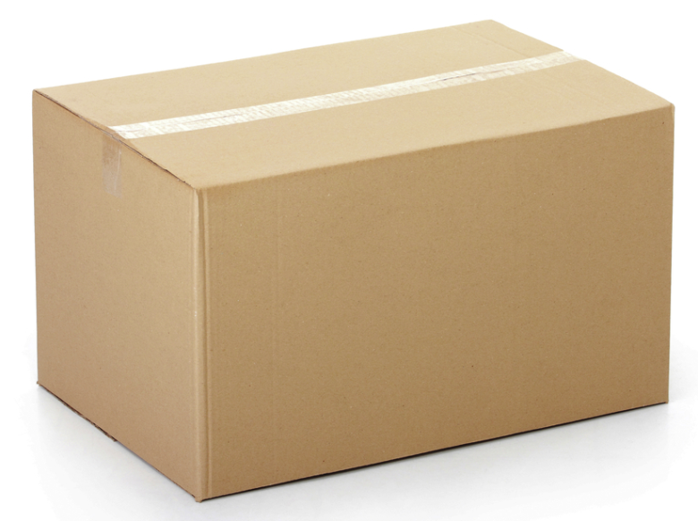

### An app to make your trigonometry homework a bit easier!

You may wonder, what does that box have to do with trigonometry.

During trigonometry homework you might receive the question to calculate the distance between two opposite corners of a box, i.e., on opposite sides of the center of the box. Well, now there is an app for that!

To calculate this distance three variables are needed,

- Height,
- Depth, and,
- Length

of the box.

### However, there is one more degree of freedom

The plane direction through the box is also important.

There are two possible directions of the diagonal plane through the box. The plane could go,

- from left to right, or,
- from front to back

of the box.

### And there is something more..

In addition, the angles between the plane diagonal and the vertical and horizontal line of the diagonal plane are calculated. This is done through use of the arctangent. As an example, a simple plot of the angles for a tangent between 0 and 5 is shown below.

Enough talk, it is time to try out [the app](https://pieteroverdevest.shinyapps.io/final_assignment_-_developing_data_products/) yourself!

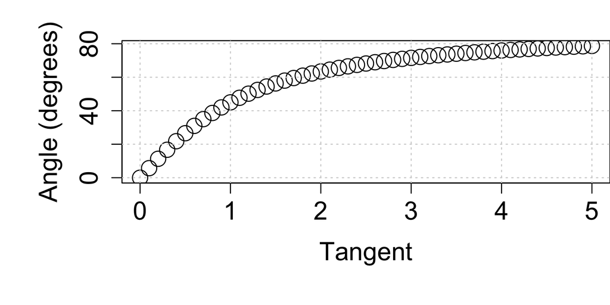

```r
par(mar=c(6,6,2,0)); x <- seq(0,5,0.1); plot(x, atan(x)/pi*180, cex=2, cex.axis=1.5, cex.lab=1.5, xlab = "Tangent", ylab = "Angle (degrees)"); grid()
```